# {detourr}: Interactive and Performant Tour Animations

The tour provides a useful vehicle for exploring high dimensional datasets. It works by combining a sequence of projections—the tour path—in to an animation—the display method. Current display implementations in R are limited in their interactivity and portability, and give poor performance and jerky animations even for small datasets. We take a detour into web technologies, such as Three.js and WebGL, to support smooth and performant tour visualisations. The R package {detourr} implements a set of display tools using {htmlwidgets} and TypeScript that allow for rich interactions (including orbit controls, scrubbing, and brushing) and smooth animations for large datasets. It provides a declarative R interface which is accessible to new users, and it supports linked views using {crosstalk} and {shiny}. The resulting animations are portable across a wide range of browsers and devices. We also extend the radial transformation of the Sage Tour (Laa et al. (2021)) to 3 or more dimensions with an implementation in 3D, and provide a simplified implementation of the Slice Tour (Laa et al. (2020)).

Casper Hart (University of Auckland)  
2022-07-05

# Introduction

An important first step in any data analysis task is to plot the data so that we can get an intuitive understanding of its structure, for example identifying the presence of clusters or outliers. When the data consists of one or two variables this is quite straightforward, but as the dimensionality of the data increases it becomes more difficult to visualise.

Several methods exist for high dimensional data visualisation. Given a data matrix $\mathbf X$ we can simply plot each variable $X_1 \dots X_p$ against the others in a pairwise fashion with the result being a scatterplot matrix (e.g. (Becker and Cleveland 1987)). We can also view projections of our data by calculating $\mathbf Y = \mathbf X \mathbf A$ where $\mathbf A$ is a $p \times d$ projection matrix with $d$ usually being 1 or 2. We can choose $\mathbf A$ in several different ways, some examples being Principal Component Analysis (PCA) which chooses the directions which explain the maximum variance, and Linear Descriminant Analysis (LDA) which maximises the ratio of between-group and within-group sums of squares. The scatterplot matrix can also be thought of as a projection method where the projections are parallel to each pair of coordinate axes. These are all examples of *linear dimension reduction* techniques, but non-linear techniques are also available such as t-SNE (Van der Maaten and Hinton 2008) and UMAP (McInnes et al. 2018) that aim to preserve both local and global structure of the data.

Rather than generating a single static visual, the *tour* (Asimov 1985); (Buja et al. 2005) works by combining a smooth sequence of projections in to an animation, which can then be viewed using a variety of different *display methods* (Wickham et al. 2011). This allows the viewer to explore the data from a number of different perspectives while being able to visually connect what would otherwise be disjointed views. However, existing display implementations for tours in R are limited in their interactivity, performance, and portability, and generally result in jerky animations even for small datasets.

# Background and related works

At its core, the tour is a sequence of projections of a data set that are combined together to form an animation. If we denote an $n \times p$ data matrix $\mathbf X$ and a $p \times d$ projection matrix $\mathbf A$, then we can denote our $n \times d$ projected data set $\mathbf Y$ as $\mathbf Y = \mathbf X \mathbf A$.

Each projection matrix $\mathbf A$ is often referred to as a *plane*, *frame*, or *basis*. (Note that in this paper, the term *frame* is avoided in this context to avoid ambiguity with *animation frames*). These bases are constrained to be orthonormal, so each column of $\mathbf A$ is a unit vector, and is orthogonal to each other column. In order to produce a smooth animation, a set of target bases are selected and interpolated between. Geodesic interpolation is generally used as described in (Buja et al. 2005).

## Types of tours

Different tour paths arise from using different methods for selecting the target bases. For example, the *grand tour* was introduced by (Asimov 1985) and chooses a set of target projections at random. This can be thought of as a random walk around projections of the data.

The projection pursuit guided tour chooses bases to find a more interesting projection than the current one, where the interestingness is defined by some index function. Index functions such as *central mass*, *holes*, and *lda* are described in (Cook et al. 2007).

Other types of tours include the *little tour*, which ensures bases parallel to the axes are visited; the *frozen tour* will fix some of the values in the projection matrix $\mathbf A$ between bases; the local tour chooses bases that are within some angular distance of the starting basis.

In all of these, the tour path is calculated in two steps; the target basis is calculated and then interpolation is done so that the transition to the next basis is smooth. Some methods generate the tour path in a single step, for example the langevitour package in R (Harrison 2022) produces tours as more of a physics simulation where points have position, velocity, momentum, and damping, and the position of points in subsequent animation frames is allowed to evolve while taking in to account user interactions.

## Display methods

The typical display methods for tours include histograms or density plots for 1D projections, and x-y scatter plots for 2D ones. 3D data can be viewed by a 3D scatterplot with a virtual perspective camera to enable displaying on a monitor. This can be enhanced with fog to make closer points more prominent, and interactive rotation controls to give a more immersive 3D experience. Projections with 3 or more dimensions can be displayed using parallel coordinates plots. Other displays exist such as Andrew’s plot (Andrews 1972), where each point is represented by a fourier curve plotted between $-\pi$ and $\pi$.

Furthermore, the data may be transformed after being projected. One consequence of the curse of dimensionality is that when projecting from high to low dimensions, the points tend to crowd towards the center. (Laa et al. 2021) describes the *sage tour*, and provides a radial transformation that ensures the relative volume at a radius $r$ in the data space is preserved in the projected space. The effect of this is that the crowding is reduced, and uniformly distributed data in the original space will continue to be uniform in the projected space.

## Software implementations

The tourr package (Wickham et al. 2011) is the most prevalent and comprehensive software in R (R Core Team 2021) for visualising tours. It implements many of the tour paths described previously including grand, little, guided, frozen, etc. and display methods including scatter plots (with variations for the sage and slice tour), parallel coordinates plots, depth displays, Andrew’s plot. The package also allows exporting tours as GIF images via the gifski package (Ooms 2021), or exporting to GGobi (Swayne et al. 2003) to allow for interaction and linked brushing, etc. However, the tourr package uses the R graphics device as the primary display, which is quite limited in performance and interactivity.

The spinifex package (Spyrison and Cook 2020) provides manual tours built on tourr and using R shiny (Chang et al. 2021), and allows the user to manipulate the contribution of each variable one at a time. The liminal R package (Lee 2021) provides an interactive gadget for displaying tour visuals. Linked selection and brushing is implemented on both visuals, and play / pause / restart controls are provided.

The langevitour R package instead uses the htmlwidgets package (Vaidyanathan et al. 2021) to display the tour. The main calculations are performed in JavaScript and the points are displayed as a scatter plot using HTML5 Canvas. The displays have good performance so large numbers of data points can be plotted with the animation remaining smooth, and includes interactive features such as drag-and-drop of additional plot elements, and modifying parameters of the tour and having the changes reflected in real time. Once the tour visualisation is generated it then no longer relies on the R runtime so it can be easily exported and embedded on a website for example. But this package is developed with a particular focus of visualising physics dynamics, rather than the more classical tour methods like in tourr.

(Kipp et al. 2019) uses D3.js (Bostock et al. 2011) combined with the R shiny (Chang et al. 2021) package to display dynamic tour visualisations. However, this setup had limited performance; the client-server nature of shiny led to inconsistent frame rates, and the number of points that could be drawn was limited to <2000 because of the limitations of SVG when drawing many individual elements.

# {detourr} usage and interactivity

The {tourr} package implements a functional approach to building tours can be intimidating to new users. Further, the use of the R graphics device and exporting of GIF images limit the interactivity that can be achieved. When designing the user API for {detourr} a data-oriented approach is taken to make it more approachable, and the visuals are built in JavaScript to enable rich user interactions. {detourr} also supports the full suite of tour path generating functions from the {tourr} package. The result is an experience that is powerful, immersive, and accessible to newcomers.

This chapter is structured as follows. The first section describes the user API in R and supported features, the second describes how the user can interact with the resulting visual. Throughout the chapter, we use the `pdfSense` dataset (Wang et al. (2018); Lee (2021)) to provide a running example. This data set consists of 2808 observations and 56 input variables from CT14HERA parton distribution function fits. The first 6 principal components are used to create the tour, accounting for ~55% of the variance in the data.

## User interface

{detourr} has a data-oriented user interface heavily influenced by the Tidy Data (Wickham (2014)) workflow, Grammar of Graphics (Wilkinson (2012); Wickham (2010)), and {ggplot2} (Wickham (2016)). The visualisation is built in a sequence of steps which follow the logical flow of data in the tour building process, which makes the API intuitive and accessible.

### Instantiating the tour

To begin, we instantiate a tour using the `detour()` function:

```r
p <- detour(pdf_df, tour_aes(
    projection = starts_with("PC"),
    colour = Type,
    label = ID
))
```

The first argument to `detour()` is a data frame in tidy format containing the tour data and aesthetics. Enforcing the use of data frames encourages data-centric statistical thinking. The second argument defines the aesthetic mapping of data variables through the `tour_aes()` function, similar to {ggplot2}. The currently supported aesthetics are:

- `projection`: (required) the numeric columns to be projected
- `colour`: point colour
- `label`: label text to be shown when the mouse is hovered over a point.

These mappings support tidy evaluation and {tidyselect} syntax (Henry and Wickham (2022)) such as `starts_with()`, `where(is.numeric())`, column ranges using `col_1:col_n`, negation `-col_n`, and others, for easier column selection.

### Generating the tour path

Once the tour is initialised with the data and aesthetics, the tour path is defined by piping the output from `detour()` to the `tour_path()` function. Note that `|>` is the pipe operator introduced in R 4.1:

```r
p <- p |> tour_path(grand_tour(3))
p
```

```
# A tibble: 464 × 2
  is_new_basis projection_matrix
  <lgl>        <list>
1 TRUE         <dbl [6 × 3]>
2 FALSE        <dbl [6 × 3]>
3 FALSE        <dbl [6 × 3]>
4 FALSE        <dbl [6 × 3]>
5 FALSE        <dbl [6 × 3]>
# … with 459 more rows
```

The `tour_path()` function defines parameters for the tour such as:

- `tour_path`: the tour path generator, e.g. `grand_tour()`, `guided_tour()`, or any other path generator compatible with the {tourr} package
- `start`: the starting basis or projection matrix
- `fps` frames per second with which to display the animation. Defaults to 30 but can be increased for a smoother animation or decreased for very large data.
- `max_bases`: the number of basis frames to generate. A higher number will give a longer tour animation.

The resulting `detour` object is stored in a standard data frame for easy consumption and inspection. It contains the full details of the tour path, where the $i^{th}$ row corresponds to the $i^{th}$ animation frame of the tour, with the following columns:

1. `is_new_basis`: whether the projection matrix corresponds to a new basis (`TRUE`) or is interpolated (`FALSE`)
2. `projection_matrix`: the projection matrix.

This form gives the user full visibility of the tour path, and allows the projection matrices to be traced and extracted for further analyses.

### Creating the animation

To display the tour animation, we simply pipe the output of `tour_path()` to any of the functions prefixed with `show_` provided by the {detourr} package. The available display functions are:

- `show_scatter()`: the core 2D or 3D scatter plot display
- `show_slice()`: a slice tour display based on Laa et al. (2020)
- `show_sage()`: a sage tour implementation based on Laa et al. (2021)

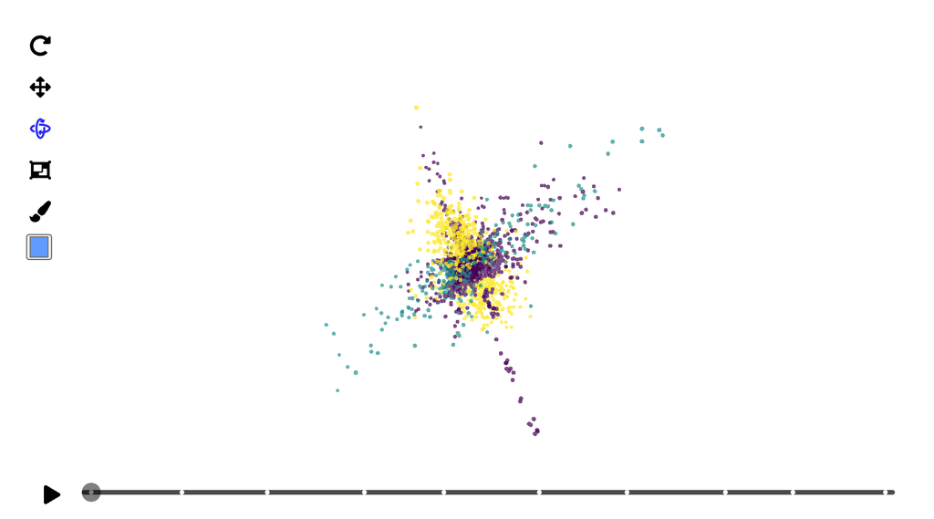

Figure 1: Initial frame of the scatterplot display generated by the `show\_scatter` display function. Controls are on the left, and an interactive timeline is on the bottom of the plot.

```r
p |> show_scatter(axes = FALSE)
```

The output of `tour_path()` becomes the input of `show_*()`, forming a fluent pipeline. For the three display methods described above, the common parameters are:

- `palette`: the colour palette to use for the tour.
- `center`: whether the data should be centered before displaying.
- `axes`: whether to show axis / what the axis titles should be
- `edges`: a two-column numeric matrix defining indices of points where line segments should be drawn between
- `paused`: whether the animation should be initialised in a paused state.
- `scale_factor`: used to scale the points in or out so that they appear on a sensible range.

Putting all of this together, we have:

```r
detour(pdf_df, tour_aes(
    projection = starts_with("PC"),
    colour = Type,
    label = ID
)) |>
    tour_path(grand_tour(3)) |>
    show_scatter()
```

This chaining process allows us to construct the tour visualisation incrementally in a way that is intuitive and easy to follow. The user is able to inspect the result at each step in the chain, and it aligns well with the *grammar of graphics* and *tidy data* workflows. This makes {detourr} accessible to newcomers who may not have worked with tours previously.

## Interactivity

Presently, several well-developed R packages allow the use of web technologies in R; {HTMLWidgets} allows binding R code with HTML and JavaScript to create standalone widgets; {shiny} provides features for combining various elements in to interactive web applications powered by R; {crosstalk} (Cheng and Sievert (2022)) enables linked selection and brushing between different HTML Widgets; and {rmarkdown} (Allaire et al. (2022)) allows creating HTML documents with HTML Widgets embedded within. The use of web technologies such as JavaScript enable the resulting visuals to be portable and accessible, and enable the implementation of rich interactive features. In this section we will describe these interactive features and how they can be configured.

### Label aesthetics

In the above example, labels are defined within the call to `tour_aes()`, which contains all of the aesthetic mappings for the tour. The `label` aesthetic produces a tooltip which is shown whenever the mouse is hovered over the data point. By default, the text in the tooltip will have the format `column_name: value`, with each specified column on a new line. If users want more control over what appears in the tooltip, one can use the `I()` function so that the values in the aesthetic column appear as-is. For example in 2, the left plot specifies the label aesthetic as `label = c(InFit, Type, ID, pt, x, mu)` and the right is specifies the label as-is by using `label = I(ID)` in the call to `tour_aes()`. When using the `I()` function for the label aesthetic, only one column can be specified at a time.

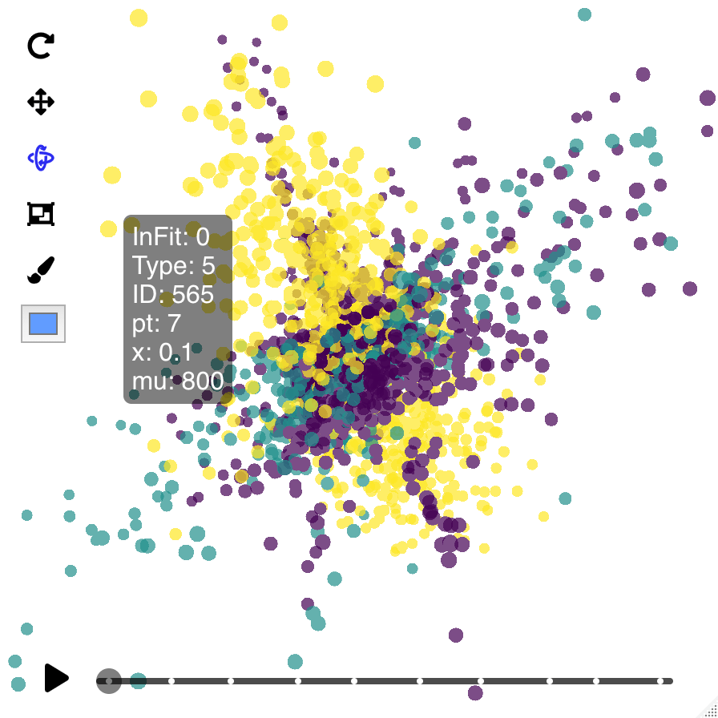

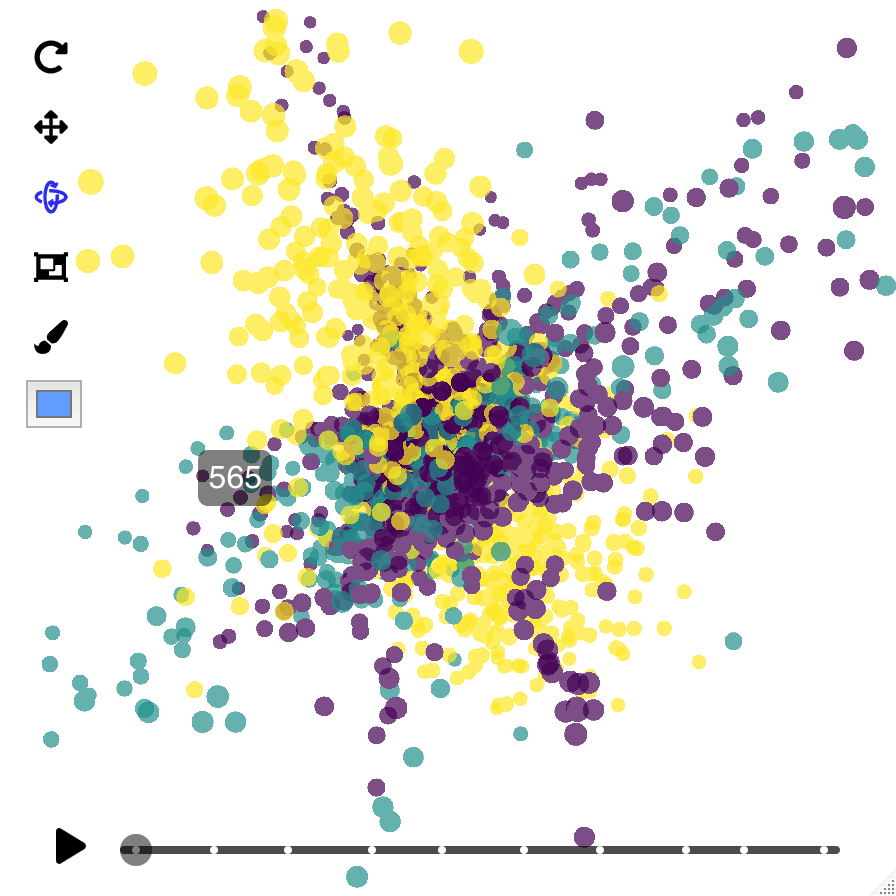

Figure 2: (left) Tooltip showing data from the 6 columns specified in the `label` aesthetic. Note that both the column names and values are present in the tooltip. (right) the `ID` column is provided as-is to the label aesthetic via the `I()` function.

### Controls

Table 1 shows a breakdown of the controls found on the left side of the visual. Note that the icon for the currently selected control will be highlighted blue; otherwise it will be black. When the icons are hovered over in the `show_scatter()` widget, alternative text will be shown.

Table 1: An overview of the interactive controls available in the detourr displays

Control

Icon

Description

Orbit

[figure not shown]

When the `show_scatter()` widget is generated, orbit controls will be enabled by default. This allows click and drag to rotate the visual, and scrolling/pinching to zoom. Note that orbit controls for the 2D variant work best if dragging from left to right, not up and down. Also note that the icon for the currently selected control will be highlighted blue; otherwise it will be black.

Pan

[figure not shown]

The pan control also allows scrolling to zoom, and click and drag to pan.

Box Selection

[figure not shown]

The selection control allows for transitory box selection by brushing. Holding the `shift` key will allow for persistent selection, and points outside of the selection will be indicated by increased transparency. There is currently a limitation where only visible points can be selected. If a point is completely obscured by other points, it will not be selected.

Brush

[figure not shown]

The brush button will apply the current colour to the selected points.

Colour Selector

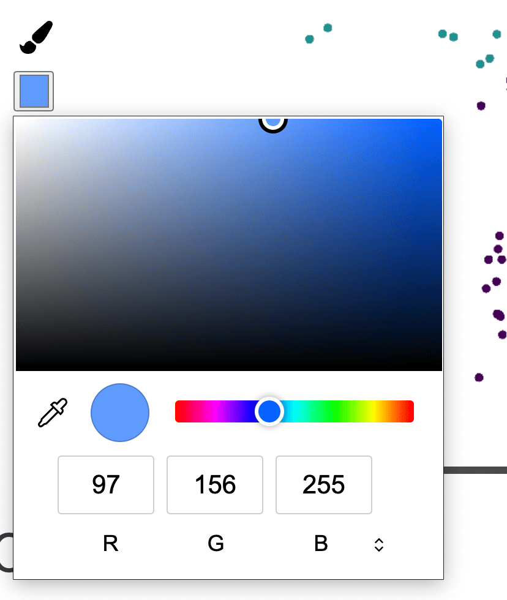

The colour selector will look slightly different depending on the browser being used. When the colour selection is changed, the selected points will be updated immediately.

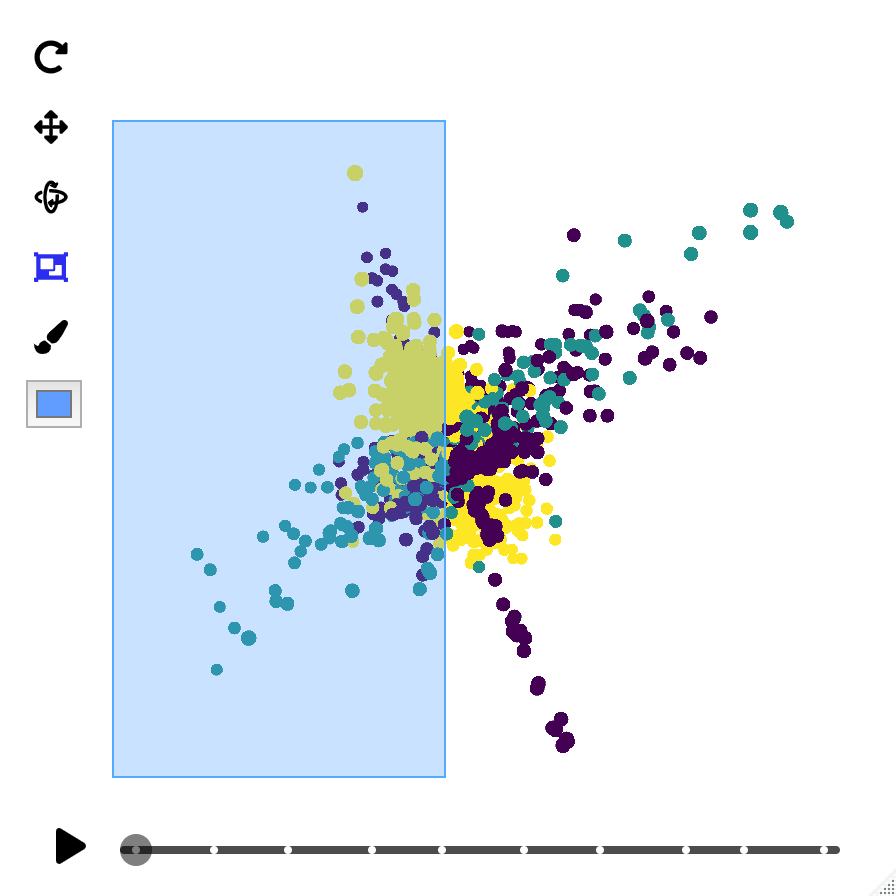

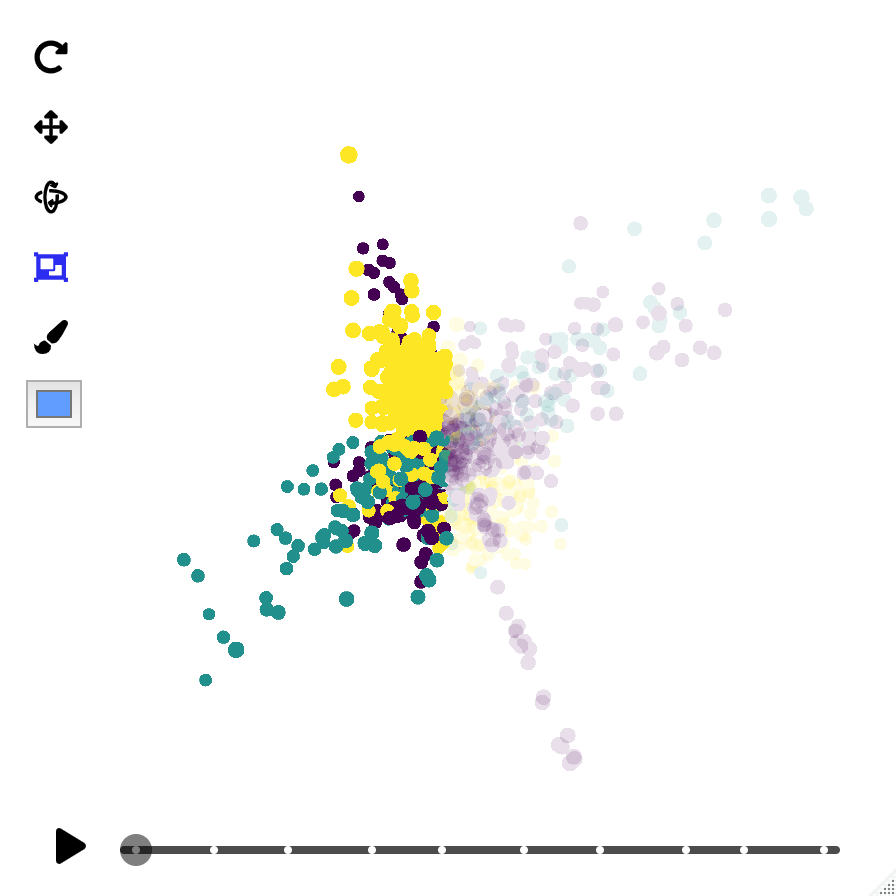

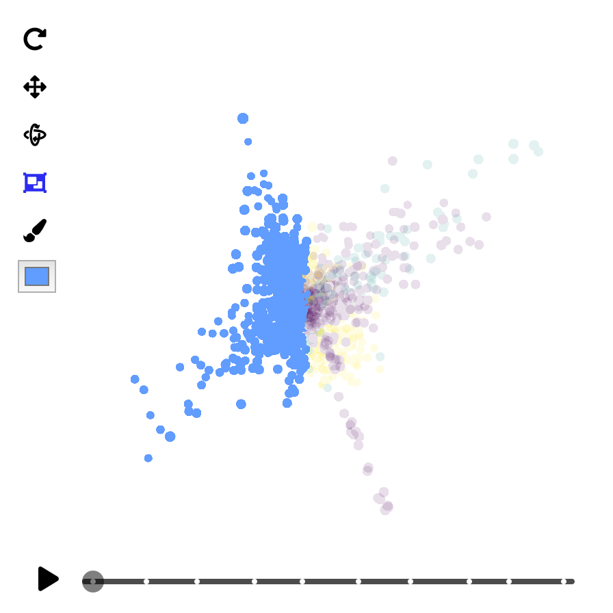

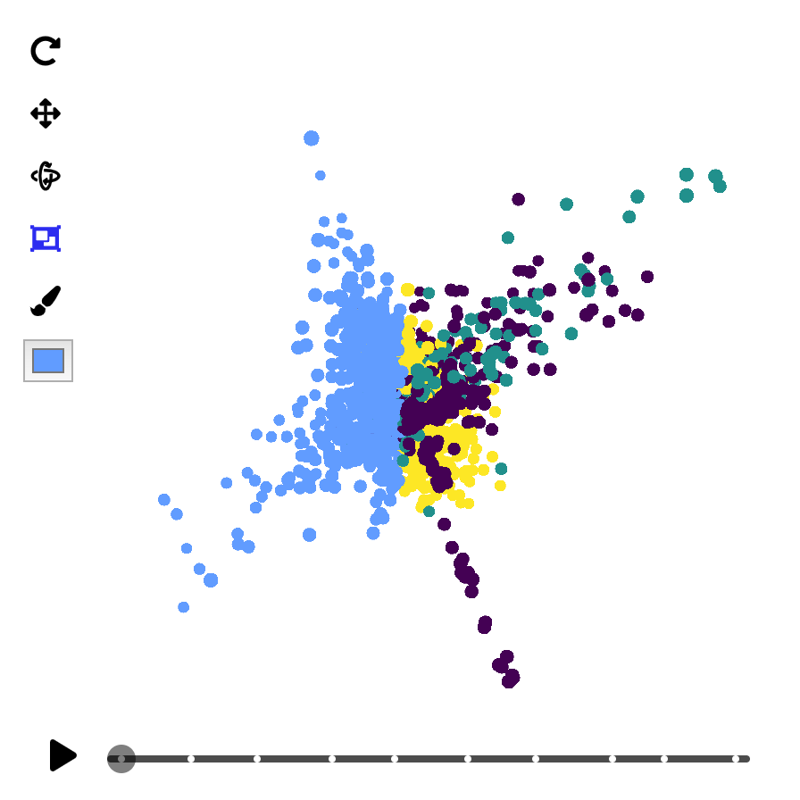

Figure 3: An illustration of the box selection and brush tool being used together.

### Timeline controls

The timeline at the bottom of the widget controls play and pause, and allows for scrubbing to a specific point in the tour. The timeline can also be used to jump to a specific basis by clicking on any of the white basis markers, and hovering the mouse over the basis markers will display the index of that basis.

# Web technologies for performance

One of the goals of this work is to improve upon the animation performance of existing tour displays. {detourr} uses several different web technologies to maximise performance so that smooth animations can be played with large data sets consisting of upwards of 100k data points. This performance also enables the animations to work with less powerful devices, making {detourr} accessible to a wider range of users.

The primary technology that allows for high-performance data visualisation is JavaScript itself. JavaScript engines in browsers such as Chrome and Firefox are highly optimised, leveraging methods such as Just-In-Time (JIT) compilation for improved runtime speed. However JavaScript is single-threaded, dynamically typed, and garbage collected, so despite these optimisations we can still run in to performance bottlenecks in some situations.

Figure 4 shows a simplified overview of the data flow in {detourr} when creating and viewing a widget. On the left are the operations that are performed by R, which only occur once when the visual is first created and have a minimal performance impact. On the right are the main operations performed by JavaScript when the widget is displayed in a browser or IDE. Linear algebra and rendering operations need to run 30 times per second, so the technology decisions surrounding them have a big impact on performance. These technology decisions and are discussed in this chapter.

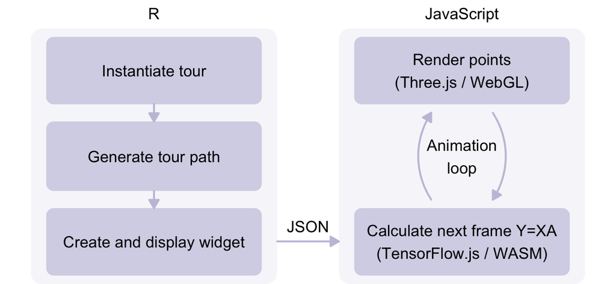

Figure 4: An overview of the data flow when creating a detourr visualisation. The full tour path is generated in R and then passed to JavaScript when the widget is created. The operations that occur in the animation loop in JavaScript are the most important to optimise.

## Linear algebra operations

The single-threaded nature of JavaScript makes matrix multiplication a performance bottleneck. At each animation frame, we must calculate the product $\mathbf{XA}$ where $\mathbf{X}$ is our data matrix and $\mathbf{A}$ is our projection matrix. The slice tour generated by the `show_slice()` display function requires an additional step of calculating the distance from each point to the projection plane which involves several more matrix operations.

To address this, {detourr} uses TensorFlow.js (Abadi et al. (2016)) as the main library for storing data and projection matrices and performing matrix operations. TensorFlow.js requires the user chose between one of three available backends:

**CPU** is a single-threaded JavaScript implementation which carries with it the limitations of JavaScript dynamic typing and garbage collection causing non-deterministic slow-downs at runtime.

**WebAssembly** (WASM) is a binary format that is used as a compilation target allowing code written in other languages like C, C++, and Rust to be run in the browser. This circumvents the dynamic typing and garbage collection limitations of JavaScript and allows near-native execution speed. The TensorFlow WASM backend uses the XNNPACK library from Google to accelerate matrix operations, which can run operations in parallel using threads and SIMD (Single Instruction Multiple Data).

**WebGL**: uses WebGL shaders to perform matrix operations on the GPU. According to the documentation, the performance benefit is primarily seen with large and complex deep learning models, so is unlikely to provide much benefit over the WebAssembly backend for our use case, and so is not investigated further in this section.

## Performance comparison

To compare these backend options a simple performance profile was run in Microsoft Edge (Chromium) on a Macbook Pro 2019 (i7, 32Gb RAM). The implementations that were compared were:

- *Hand Coded*: a manual JavaScript implementation coded using `for` loops, operating on nested arrays representing data and projection matrices.
- *TensorFlow CPU*: the vanilla single-threaded CPU backend for TensorFlow.js.
- *TensorFlow WASM*: the TensorFlow.js WASM backend.

These backends were compared across 3 datasets of different sizes and complexity, using a 2D Grand Tour:

- *pdfsense*: The same data set used throughout this chapter; 2808 observations across 56 variables, taking the first 6 principal components for the tour.
- *mnist_embeddings_8d*: 8-dimensional embeddings of the MNIST dataset, with a total of 10k observations.
- *mnist_embeddings_32d*: 32-dimensional embeddings of the MNIST dataset, again with 10k observations.

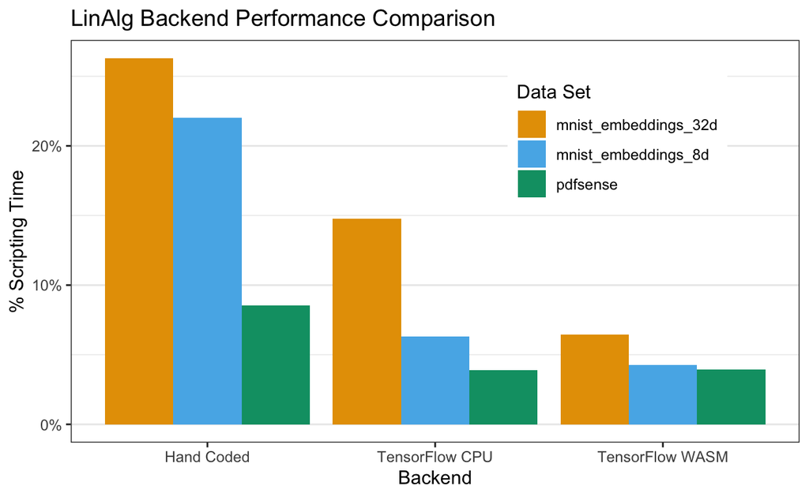

Figure 5: Performance comparison across different data sets and backends. TensorFlow provides better performance than a hand-coded implementation across the board. For smaller datasets like pdfsense, there is little difference between CPU and WASM backends for TensorFlow.js, but for larger dataset WASM performs much better.

Figure 5 shows the performance of the three backends across the example datasets. TensorFlow provides better performance across the board when compared to the hand-coded implementation, but the difference between the CPU and WASM backends only becomes apparent with the larger MNIST embeddings datasets. Note that the metric `% Scripting Time` is the time spent across *all* JavaScript scripting for the visual, and not just the time spend on linear algebra operations. This is why we see such diminishing returns with the smaller *pdfsense* dataset.

Another important comparison is the performance of the `show_slice()` display function between these datasets. The slice tour uses additional matrix operations to calculate the distance from each point to the projection plane, so the benefit of WASM backend is even more apparent. This is shown in Figure 6

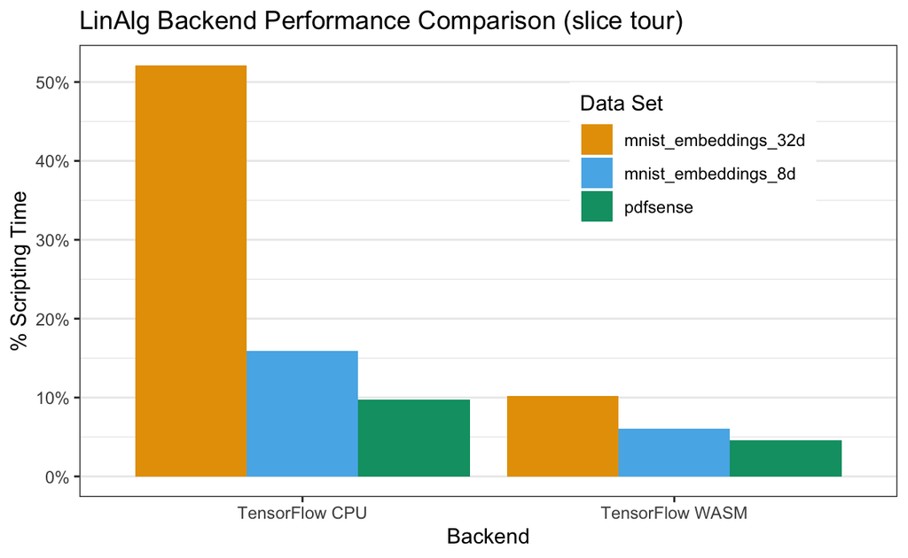

Figure 6: The additional matrix operations required by the slice tour display function make the performance benefit of the WASM backend much more apparent.

## Rendering

When displaying data visuals using JavaScript in a browser, there are three main technologies that can be used:

**SVG** is commonly used for web-based visuals, including in software such as D3.js (Bostock et al. (2011)) with good support for interaction and animation. Kipp et al. (2019) uses D3.js with SVG for rendering tours, but describes performance issues when the number of points gets close to 2,000. This is because while SVG is suitable for drawing large and complex shapes, performance can degrade when rendering many individual shapes.

**HTML5 Canvas (2D)** uses a canvas element with a 2D rendering context and provides good performance, allowing many thousand data points to be used with smooth animation. This is the rendering method used by the {langevitour} package, and provides much better performance over SVG for this use case.

**HTML5 Canvas (WebGL)** uses the WebGL rendering context with GPU acceleration to achieve high performance, and is used by a range of browser-based 3D animations and games. This typically provides higher performance than using the 2D canvas rendering context.

{detourr} implements **HTML5 Canvas** with the **WebGL** rendering context using the Three.js (Cabello (2010)) library. This is the same library that powers the TensorFlow Embedding Projector (Smilkov et al. (2016)), and allows for flexible and performant 2D and 3D data visuals.

One downside of using HTML5 Canvas elements is that custom logic is needed to determine where the mouse pointer is relative to visual elements when interactions occur. This issue is resolved is by rendering the image twice; the first pass renders to the screen and the second renders to an invisible ‘picking’ scene. The colours of the points in this picking scene correspond to the ID of the point that was rendered. When a mouse is hovered over a pixel or a set of pixels are selected, we simply check their colour in the picking scene to determine which point IDs relate to the event. Rendering the scene twice at each frame makes performance all the more important.

Despite this extra step, a naive performance benchmark of the rendering performance of {detourr} using the `mnist_embeddings_8d` data set at 30 FPS shows only 3% of the time is devoted to rendering and painting points, which for our use case is negligible.

# Case study — MNIST embeddings

A common task when analysing wide or sparse data sets is to generate embeddings; finding a lower dimensional representation of high dimensional data, placing similar objects close together and dissimilar objects far apart in the embedding space. This is especially useful when dealing with text or image data.

An example of this is the algorithm used for facial recognition in FaceNet (Schroff et al. (2015)). A neural network is trained which maps a vector representation of images of faces to a lower dimensional space. The network minimises the distance between examples of the same class and maximises distances between examples from different classes in the output space. The result is that the euclidean distance between faces can be used as a metric for face similarity, so an unknown face can be classified as belonging to a specific individual if the distance between the unknown face and one or more known faces is small.

The datasets `mnist_embeddings_8d` and `mnist_embeddings_32d` in the {detourr} package are embeddings trained using a similar algorithm to FaceNet but using the MNIST (LeCun (1998)) handwritten digits dataset. The training set consists of 60,000 28x28 pixel training images and in the following examples we visualise the test set containing 10,000 examples.

## Scatterplot display

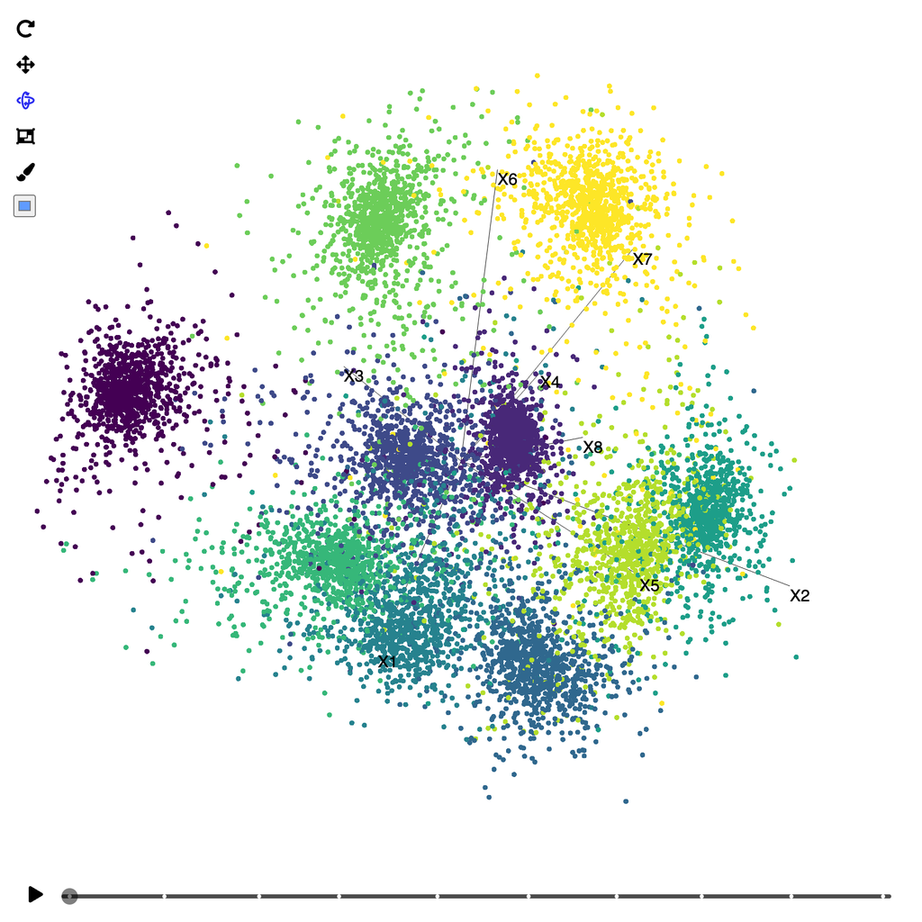

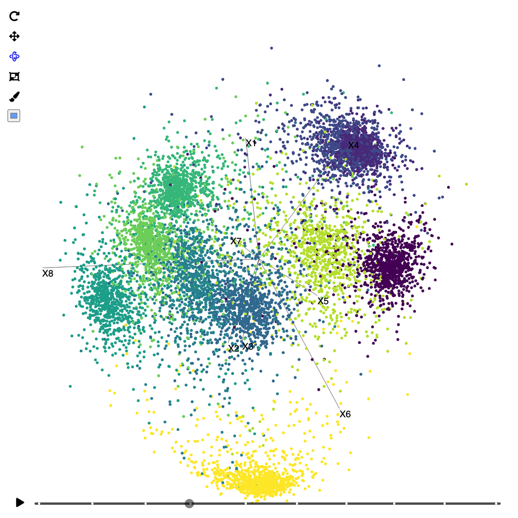

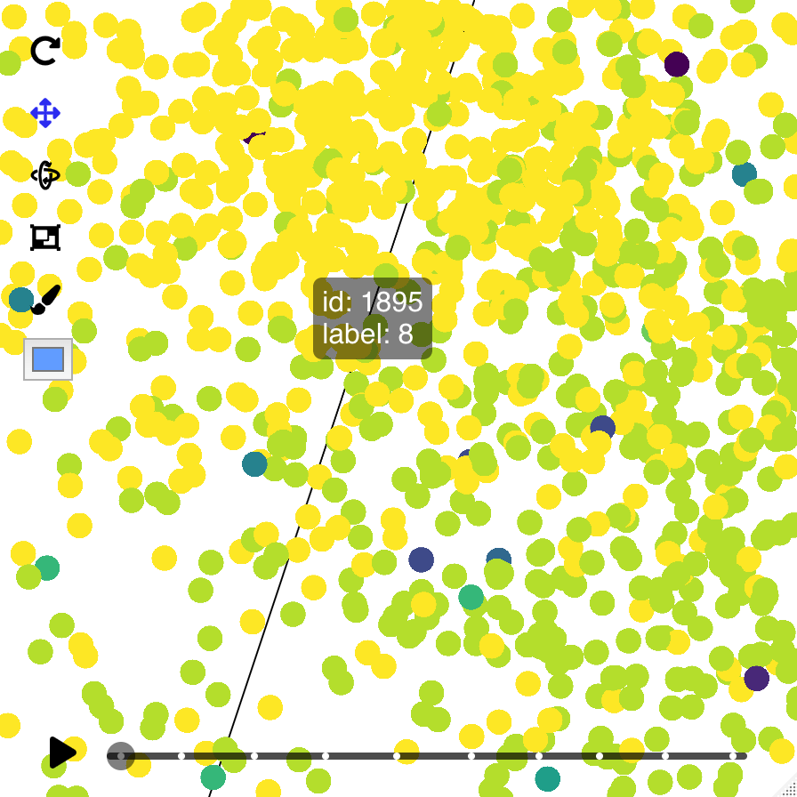

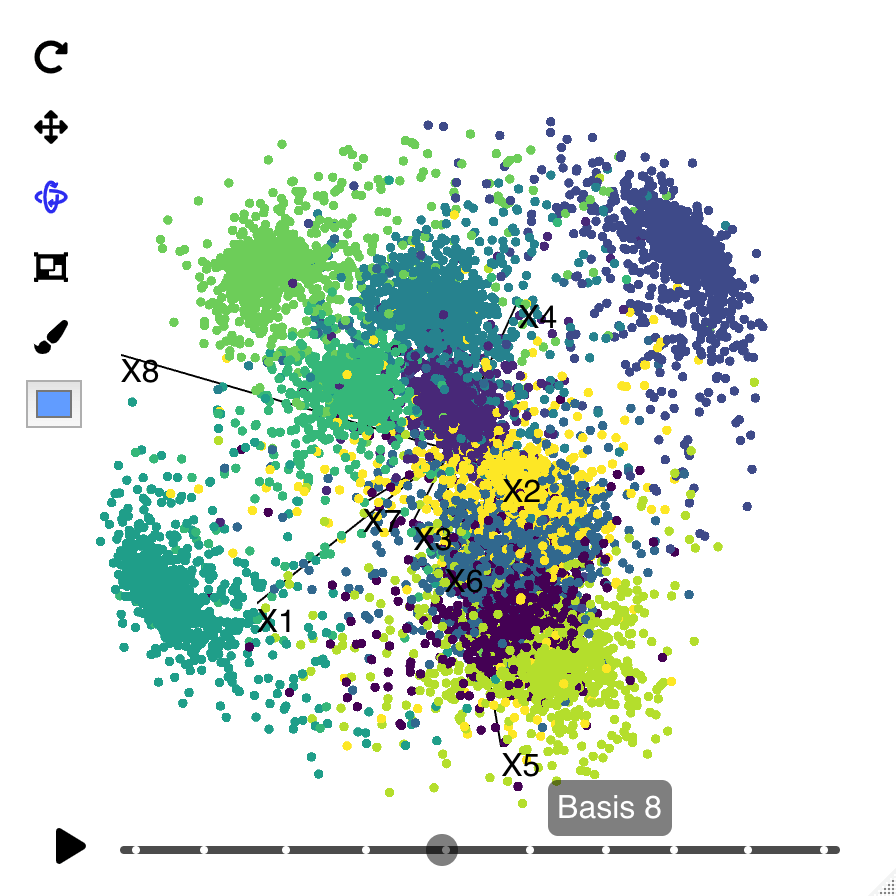

Figure 7: Selected frames from the 8-dimensional MNIST embeddings data using show_scatter() as the display method. The colour corresponds to the handwritten digit 0, 1, …, 9. Despite the large number of data points, the animation of the tour is smooth and interactions are responsive.

Using the core `show_scatter()` function to display a `grand_tour()` tour path in Figure@ref(fig:mnist-8d-scatter) we can see quite good separation between the clusters corresponding to each of the 10 digits. Despite the tour animation consisting of 10,000 data points, the animation runs smoothly at 30 FPS in Microsoft Edge on a Macbook Pro 2019. Running a performance profile of the animation indicates the CPU is idle 90% of the time while the animation is playing. The remaining time is divided between scripting (6%, including linear algebra operations), rendering (1.4%), painting (0.8%) and system (1.8%). When running the same tour on the `mnist_embeddings_32d` dataset, the animation is still quite smooth and CPU is 80% idle.

In the lower left of Figure@ref(fig:mnist-8d-scatter) is an example of the `label` aesthetic at work. This allows the user to identify which group a set of points belongs to, as well as the precise ID of any outliers that may require further investigation.

## Sage and Slice display methods

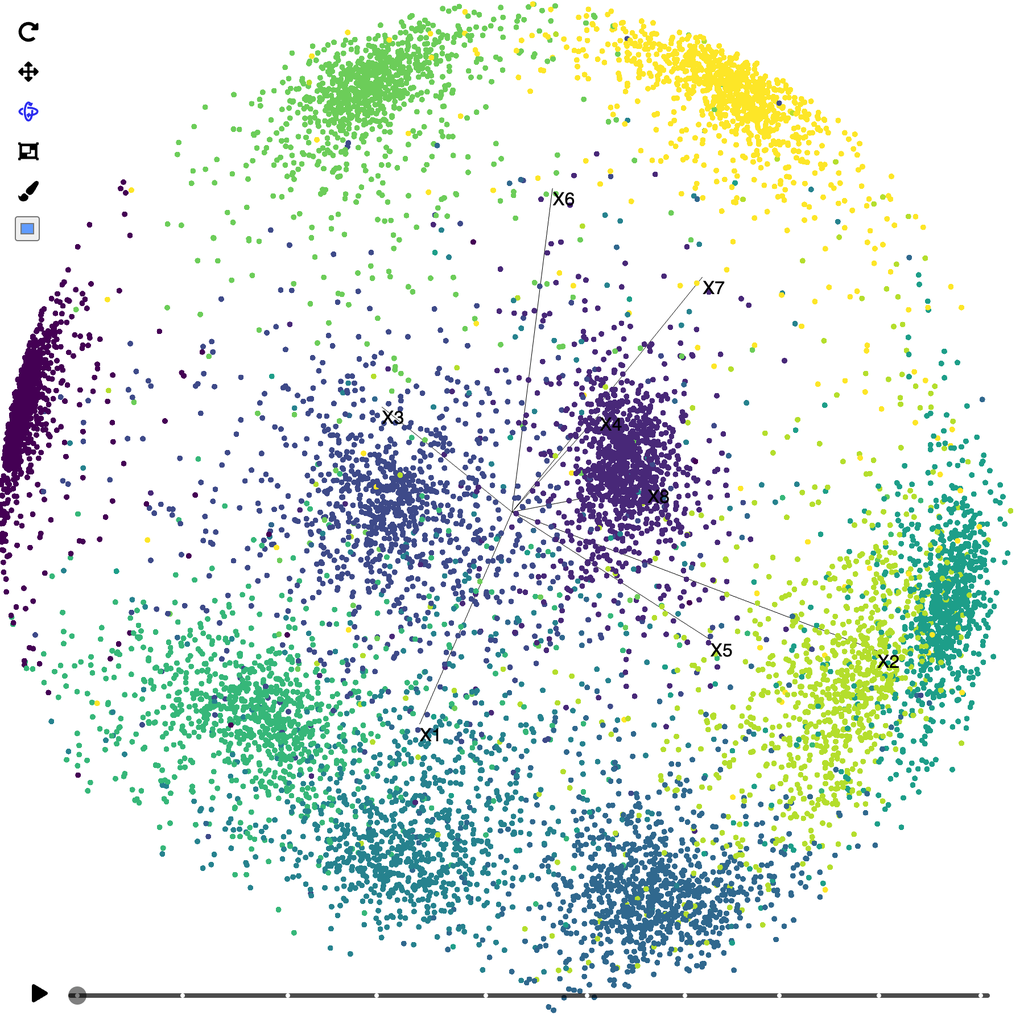

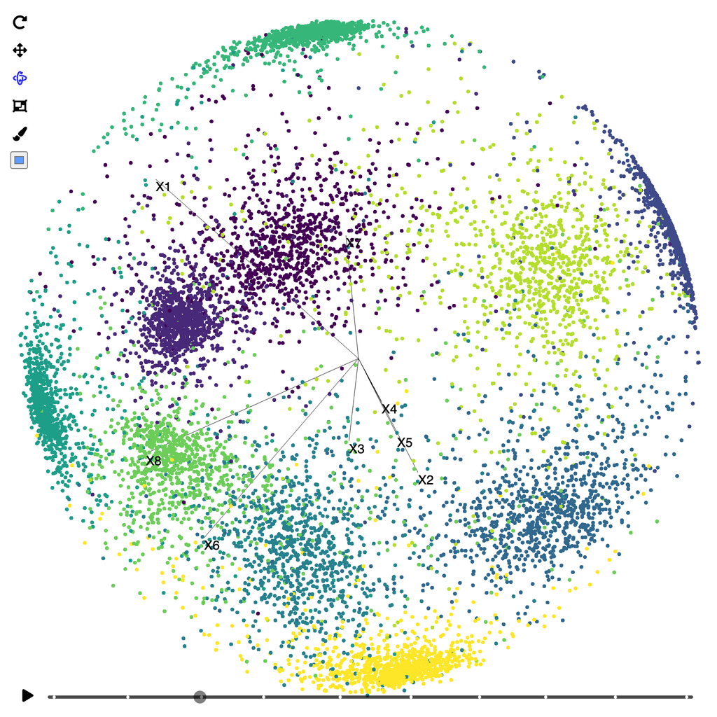

Figure 8: Selected frames from the 8-dimensional MNIST embeddings data using show_sage() as the display method with a 2D grand tour path. The sage display shows the data points near the surface of the unit ball, which is due to the L2 normalisation of the original embeddings. This structure was not clear in the standard scatter display but is preserved with the sage display.

The `show_scatter()` display method gives the viewer a fairly good sense of the data set, but there is some structure that may not be obvious. The embeddings in the `mnist_embeddings_8d` and `mnist_embeddings_32d` datasets are L2 normalised, so the points sit on the surface of a unit ball in the high-dimensional space. To reveal this structure, we can use the *sage* (Laa et al. (2021)) or *slice* (Laa et al. (2020)) display methods, which are implemented as `show_sage()` and `show_slice()` respectively.

The *sage* display scales points outwards based on their radius so that the relative volume of the circle or sphere in the projected space is the same as in the original space. In the example shown in Figure@ref(fig:mnist-8d-sage), the `show_sage()` display method is used. The effect is that the projected points tend sit much closer to the surface of the unit circle, giving a much clearer view of the ball-like structure of the original data.

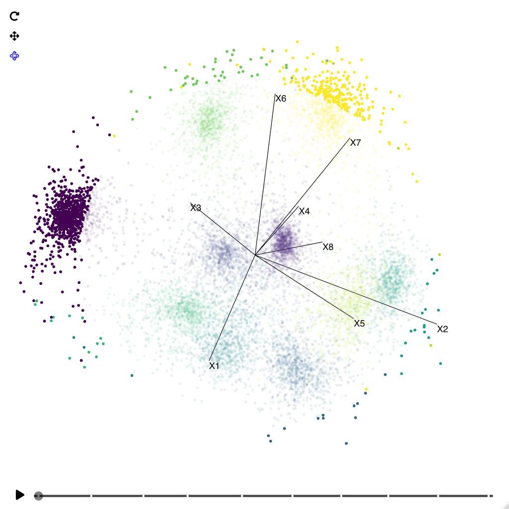

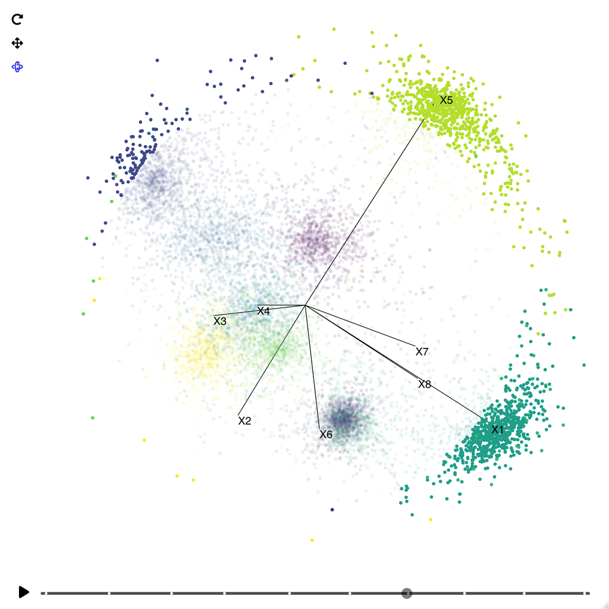

Figure 9: selected frames of the 8-dimensional MNIST embeddings data using show_slice() as the display method. The slice display makes the hollowness of this data apparent.

The *slice* display highlights points based on their proximity to the projection plane. Points that are close to the projection plane are highlighted and those further away are faded out by making them transparent. In the case of the MNIST embedding data in Figure@ref(fig:mnist-8d-slice) the ball structure of the data manifests as a clear circular void in the middle of the plot, with points highlighted only towards the edges.

## Linked selection

Plot interactions such as selection and filtering can be helpful for identifying and exploring outliers, clusters, and other interesting features in a dataset. These are enhanced even further when multiple visuals are linked, and selections and filters are applied to all linked visuals. In this example, we compare the tour animation with the result of a T-SNE (Van der Maaten and Hinton (2008)) which was performed using the excellent {Rtsne} R package (Krijthe (2015)) and displayed using {plotly}. The visuals are linked using the R package {crosstalk} (Cheng and Sievert (2022)) and a set of filter checkboxes is also added.

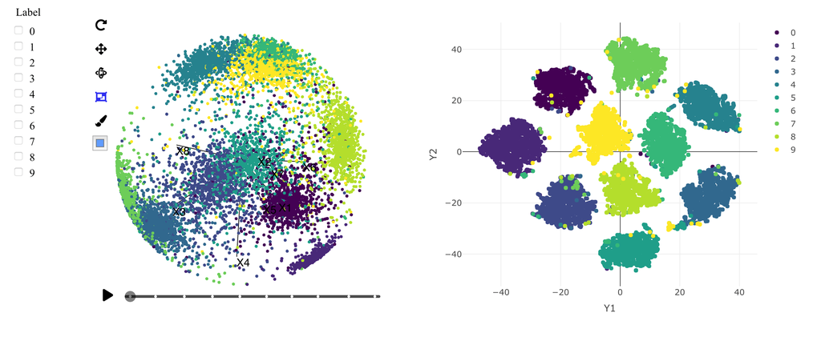

Figure 10: Linked visuals of the tour using {detourr} (left) compared to a T-SNE dimension reduction (right)

Figure 10 shows the linked visuals in their initial state with no filtering applied. We can then use the selection tool in either of the visuals to highlight points, and see the highlighting applied to both visuals as in Figure@ref(fig:linked-tsne-selection).

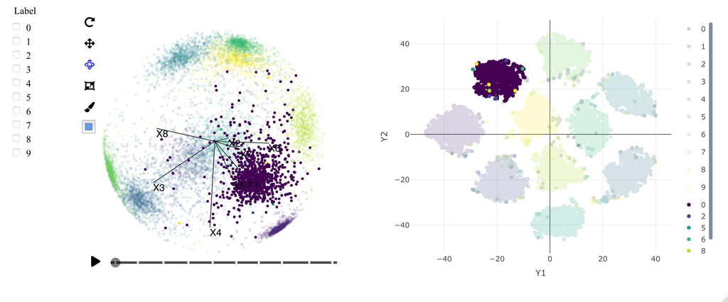

Figure 11: Linked visuals with selection applied. Points can be selected in either visual via click-and-drag and the selection will be reflected in both.

Figure 12 shows the result of filtering the visuals using the filter checkboxes on the left. In the filtered visual, outlying points are much easier to see, and they can be easily investigated using tooltips.

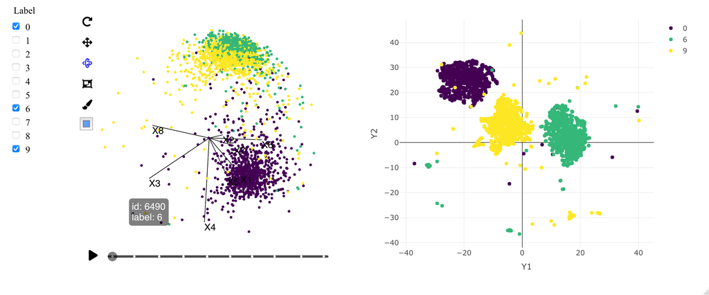

Figure 12: Linked visuals with filtering applied. Viewing each digit individually makes outlying points much more apparent, and those points can be identified using tooltips.

# Conclusion and future work

In this paper we have introduced {detour} which provides interactive, performant, and portable tour visualisations from R. We accomplish these things using web technolies; TensorFlow.js (Abadi et al. (2016)) provides fast linear algebra operations through WebAssembly, Three.js provides GPU rendering via WebGL, and JavaScript & HTML enable good performance and interactive features across the board. We also provide a simplified implementation of the Slice display (Laa et al. (2020)), and have generalised the radial transformation from the Sage display (Laa et al. (2021)) to work with tours of 3 or more dimensions. All of this is done with an intuitive user interface which makes the software accessible to new users.

Looking ahead, the priority for the next stage of development is to leverage {detourr}’s extensible design to implement additional display methods such as density plots, histograms, parallel coordinates plots, and Andrew’s plot. Additional changes could also be made to allow the radial transformation of the sage display and the highlighting of points from the slice display to be incorporated in to these other display methods, rather than being limited to only the scatter plot display. This would also allow the additional information from both the sage and slice tour applied to the same visual.

Further enhancements could be made by implementing facetting; allowing grouped data to be displayed across separate visuals with unified controls and timeline added. This could be taken further by allowing multiple *different* displays to use the same controls and timeline, for example displaying a scatter plot alongside one or more density plots.

To extend the existing scatter plot displays, the addition of an interactive legend would greatly enhance the user experience. As well as providing context for the point colour / fill, this would allow the user to be able to filter groups without needing to use a separate package like {shiny} or {crosstalk}. A shape aesthetic would also be beneficial, and the ability to export the projection matrix at the current frame would make it easier to perform analysis once an interesting projection is found.

As well as being able to display points and lines, support for plotting surfaces would allow for rich visualisations of regression model fits and classification boundaries. Three.js has good support for drawing surfaces, however it’s not clear how a decision boundary can be projected down to a lower number of dimensions or whether this is actually feasible.

Support for displaying images or sprites directly on the tour visual or as an extension of the tooltip functionality is possible. A similar feature is implemented in the Tensorboard Embedding Visualiser (Smilkov et al. (2016)) which also uses Three.js under the hood.

What’s more, Three.js has support for VR, which would be an interesting addition for exploring an immersive 3D tour visual.

# Appendix

## Radial CDF of hyperspheres projected to 3 dimensions

In order to implement the 3D variant of the sage tour (Laa et al. (2021)), we need an expression for the relative projected volume of a **sphere** of radius $R$. This is then used as a scaling factor for point radii in the visualisation to prevent points from being crowded towards the center.

First we denote the volume of a $p$-dimensional hypersphere by:

$$\frac{2\pi^{p/2}R^p}{p\Gamma(p/2)}$$

In the appendix of Laa et al. (2022) (equations 7–10) is a derivation for the relative projected volume of a ball of radius $r$.

$$\begin{align}
F(r; p, R) &= \frac{V_{inside}(r; p, R)}{ V(p, r) } \\
&= 1 - \frac{V_{outside}(r; p, R)}{ V(p, r) }
\tag{1}
\end{align}$$

And the formula for $V_{outside}(r; p, R)$ for a **circle** is given as:

$$\begin{equation}
V_{outside}(r; p, R) =
\int_r^R V(p-2, \sqrt{R^2 - x^2})2\pi x dx
\tag{2}
\end{equation}$$

To extend this to the 3-dimensional case, we can modify (2) to express the volume outside a **sphere** of radius $r$ as:

$$\begin{equation}
V_{outside}(r; p, R) = \int_r^R V(p-3, \sqrt{R^2 - x^2})4\pi x^2 dx
\end{equation}$$

and it follows that the relative projected volume for a sphere is

$$\begin{equation}
F_3(r; p, R) = 1 -
\frac{
\int_r^R V(p-3, \sqrt{R^2 - x^2})4\pi x^2 dx
}{
V(p, R)
}
\end{equation}$$

We know $2\Gamma(3/2) = \Gamma(1/2) = \sqrt{ \pi }$ so with some rearranging this can be reduced to:

$$\begin{equation}
F_3(r; p, R) = 1 - \frac{2}{R^p}
\frac{\Gamma(p/2+1)}{\Gamma(3/2)\Gamma((p-1)/2)}
\int_r^R (R^2 - x^2)^{(p-3)/2} x^2 dx \\
\end{equation}$$

Denoting $u = 1 - \left(\frac{x}{R}\right)^2$ and $dx = \frac{R^2}{-2x}du = \frac{R}{-2\sqrt{1-u}}du$ for a change of variable this becomes

$$\begin{align}
F_3(r; p, R) &= 1 -
\frac{\Gamma(p/2+1)}{\Gamma(3/2)\Gamma((p-1)/2)}
\int_0^{1-\frac{r^2}{R^2}} u^{(p-3)/2} (1-u)^{1/2} du \\
&= 1 - \mathrm{BetaInc}\left(1-\left(\frac{r}{R}\right)^2,
\frac{p-1}{2}, \frac{3}{2}\right) \\
&= \mathrm{BetaInc}\left(\left(\frac{r}{R}\right)^2, \frac{3}{2},
\frac{p-1}{2}\right)
\tag{3}
\end{align}$$

where *BetaInc* is the regularised incomplete beta function (the CDF of a Beta distribution).

We can generalise this to any projection from $p$ to $d$ dimensions using the same steps, but with

$$\begin{equation}
V_{outside}(r; p, R, d) = \int_r^R V(p-d, \sqrt{R^2 - x^2})
\frac{2\pi^{d/2}}{\Gamma(d/2)} x^{d-1} dx
\end{equation}$$

where $\frac{2\pi^{d/2}}{\Gamma(d/2)} x^{d-1}$ is the surface area of a d-ball.

This results in the relative projected volume of a projection from $p$ to $d$ dimesions being given by:

$$\begin{equation}
F(r; p, R, d) = \mathrm{BetaInc}\left(\left(\frac{r}{R}\right)^2,
\frac{d}{2}, \frac{p-d}{2}+1\right)
\tag{4}
\end{equation}$$

Figures 13 and 14 compare the theoretical results from equations (3) and (4) respectively with simulated values.

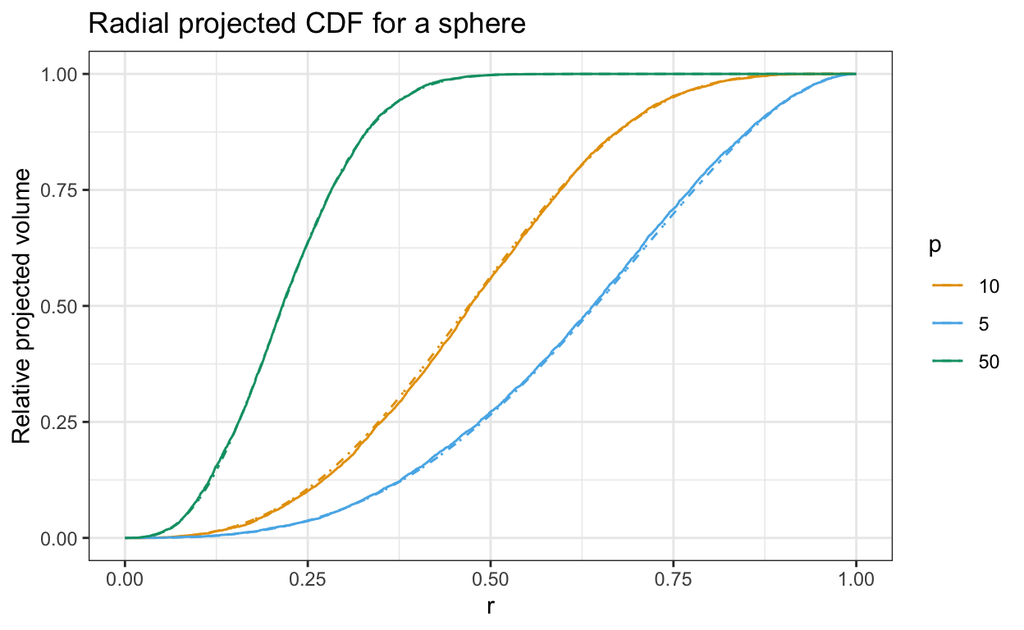

Figure 13: Relative projected volume for projections from p dimensions to d=3 dimensions. The solid line is simulated data, and the dashed line is the theoretical CDF

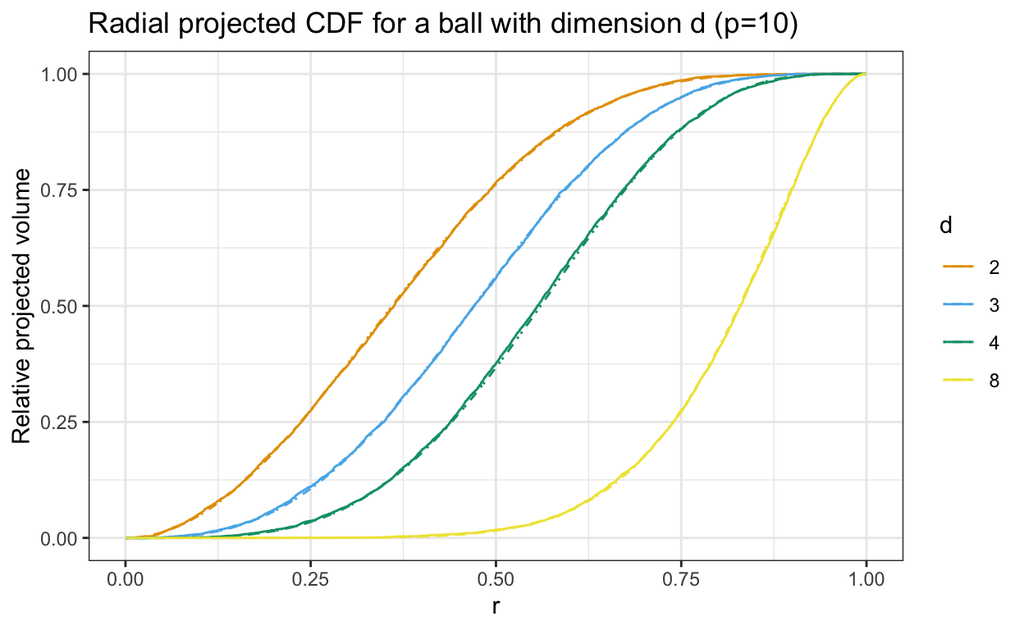

Figure 14: Relative projected volume for a projection of p=10 dimensions to d dimensions. The solid line is simulated data, and the dashed line is the theoretical CDF. This shows the generalisation to d > 3 dimensions

M. Abadi, P. Barham, J. Chen, Z. Chen, A. Davis, J. Dean, M. Devin, S. Ghemawat, G. Irving, M. Isard, et al. TensorFlow: A system for large-scale machine learning. In *12th USENIX symposium on operating systems design and implementation (OSDI 16)*, pages. 265–283 2016.

J. Allaire, Y. Xie, J. McPherson, J. Luraschi, K. Ushey, A. Atkins, H. Wickham, J. Cheng, W. Chang and R. Iannone. *Rmarkdown: Dynamic documents for r.* 2022. URL https://github.com/rstudio/rmarkdown. R package version 2.13.

D. F. Andrews. Plots of high-dimensional data. *Biometrics*, 125–136, 1972.

D. Asimov. The grand tour: A tool for viewing multidimensional data. *SIAM journal on scientific and statistical computing*, 6(1): 128–143, 1985.

R. A. Becker and W. S. Cleveland. Brushing scatterplots. *Technometrics*, 29(2): 127–142, 1987.

M. Bostock, V. Ogievetsky and J. Heer. D$^3$ data-driven documents. *IEEE transactions on visualization and computer graphics*, 17(12): 2301–2309, 2011.

A. Buja, D. Cook, D. Asimov and C. Hurley. Computational methods for high-dimensional rotations in data visualization. *Handbook of statistics*, 24: 391–413, 2005.

R. Cabello. Three.js. *GitHub repository*, 2010. URL https://github.com/mrdoob/three.js.

W. Chang, J. Cheng, J. Allaire, C. Sievert, B. Schloerke, Y. Xie, J. Allen, J. McPherson, A. Dipert and B. Borges. *Shiny: Web application framework for r.* 2021. URL {https://CRAN.R-project.org/package=shiny}. R package version 1.7.1.

J. Cheng, B. Karambelkar and Y. Xie. *Leaflet: Create interactive web maps with the JavaScript ’leaflet’ library.* 2022. URL {https://CRAN.R-project.org/package=leaflet}. R package version 2.1.1.

J. Cheng and C. Sievert. *Crosstalk: Inter-widget interactivity for HTML widgets.* 2022. URL {https://rstudio.github.io/crosstalk/}. R package version 1.2.0.9000.

D. Cook, D. F. Swayne and A. Buja. *Interactive and dynamic graphics for data analysis: With r and GGobi.* Springer Science & Business Media, 2007.

P. Harrison. *Langevitour: Langevin tour.* 2022. URL {https://CRAN.R-project.org/package=langevitour}. R package version 0.2.

L. Henry and H. Wickham. *Tidyselect: Select from a set of strings.* 2022. URL {https://CRAN.R-project.org/package=tidyselect}. R package version 1.1.2.

M. Kipp, U. Laa and D. Cook. Connecting r with D3 for dynamic graphics, to explore multivariate data with tours. *The R Journal*, 11(1): 245, 2019.

J. H. Krijthe. *Rtsne: T-distributed stochastic neighbor embedding using barnes-hut implementation.* 2015. URL https://github.com/jkrijthe/Rtsne. R package version 0.16.

U. Laa, D. Cook, A. Buja and G. Valencia. Hole or grain? A section pursuit index for finding hidden structure in multiple dimensions. *Journal of Computational and Graphical Statistics*, 0(0): 1–14, 2022. URL https://doi.org/10.1080/10618600.2022.2035230.

U. Laa, D. Cook and S. Lee. Burning sage: Reversing the curse of dimensionality in the visualization of high-dimensional data. *Journal of Computational and Graphical Statistics*, 1–10, 2021.

U. Laa, D. Cook and G. Valencia. A slice tour for finding hollowness in high-dimensional data. *Journal of Computational and Graphical Statistics*, 29(3): 681–687, 2020.

Y. LeCun. The MNIST database of handwritten digits. *http://yann. lecun. com/exdb/mnist/*, 1998.

S. Lee. *Liminal: Multivariate data visualization with tours and embeddings.* 2021. URL {https://CRAN.R-project.org/package=liminal}. R package version 0.1.2.

L. McInnes, J. Healy and J. Melville. UMAP: Uniform manifold approximation and projection for dimension reduction. 2018. URL https://arxiv.org/abs/1802.03426.

J. Ooms. *Gifski: Highest quality GIF encoder.* 2021. URL {https://CRAN.R-project.org/package=gifski}. R package version 1.4.3-1.

R Core Team. *R: A language and environment for statistical computing.* Vienna, Austria: R Foundation for Statistical Computing, 2021. URL {https://www.R-project.org/}.

F. Schroff, D. Kalenichenko and J. Philbin. Facenet: A unified embedding for face recognition and clustering. In *Proceedings of the IEEE conference on computer vision and pattern recognition*, pages. 815–823 2015.

C. Sievert. *Interactive web-based data visualization with r, plotly, and shiny.* Chapman; Hall/CRC, 2020. URL {https://plotly-r.com}.

D. Smilkov, N. Thorat, C. Nicholson, E. Reif, F. B. Viégas and M. Wattenberg. Embedding projector: Interactive visualization and interpretation of embeddings. 2016. URL https://arxiv.org/abs/1611.05469.

N. Spyrison and D. Cook. spinifex: An R Package for Creating a Manual Tour of Low- dimensional Projections of Multivariate Data. *The R Journal*, 12(1): 243–257, 2020. URL {https://doi.org/10.32614/RJ-2020-027}.

D. F. Swayne, D. T. Lang, A. Buja and D. Cook. GGobi: Evolving from XGobi into an extensible framework for interactive data visualization. *Computational Statistics & Data Analysis*, 43(4): 423–444, 2003.

R. Vaidyanathan, Y. Xie, J. Allaire, J. Cheng, C. Sievert and K. Russell. *Htmlwidgets: HTML widgets for r.* 2021. URL {https://CRAN.R-project.org/package=htmlwidgets}. R package version 1.5.4.

L. Van der Maaten and G. Hinton. Visualizing data using t-SNE. *Journal of machine learning research*, 9(11): 2008.

B.-T. Wang, T. Hobbs, S. Doyle, J. Gao, T.-J. Hou, P. M. Nadolsky and F. I. Olness. Mapping the sensitivity of hadronic experiments to nucleon structure. *Physical Review D*, 98(9): 094030, 2018.

H. Wickham. A layered grammar of graphics. *Journal of Computational and Graphical Statistics*, 19(1): 3–28, 2010.

H. Wickham. *ggplot2: Elegant graphics for data analysis.* springer, 2016.

H. Wickham. Tidy data. *The Journal of Statistical Software*, 59: 2014. URL http://www.jstatsoft.org/v59/i10/.

H. Wickham, D. Cook, H. Hofmann and A. Buja. Tourr: An r package for exploring multivariate data with projections. *Journal of Statistical Software*, 40: 1–18, 2011.

L. Wilkinson. The grammar of graphics. In *Handbook of computational statistics*, pages. 375–414 2012. Springer.

Y. Xie, J. Cheng and X. Tan. *DT: A wrapper of the JavaScript library ’DataTables’.* 2022. URL {https://CRAN.R-project.org/package=DT}. R package version 0.22.